# Тестовое задание для ЦДП

Жарахович Мария

2024-10-25

## Анализ структуры доходов граждан в разрезе муниципальных образований в 2018-2023 годах

### Загрузка данных

#### Задача 1

*Скачать данные об объеме социальных выплат и налогооблагаемых денежных доходов в разрезе муниципальных образований и версионный справочник муниципальных образований от СберИндекс.*

Загружаем в рабочую среду нашу книгу с данными и версионный справочник. Для наших задач актуальны только последние 6 листов книги (2017-2022), именно их мы и загрузим, объединив в единый датафрейм. Для датафрейма также подпишем нумерацию годов по-другому: с 2018 по 2023 (поскольку росстат публикует данные за предыдущий год).

Загружаем версионный справочник (файл “t_dict_municipal_districts”).

Группируем данные по названию муниципального образования и считаем количество уникальных кодов ОКТМО. Затем оставляем только группы с более чем 1 уникальным кодом ОКТМО. Далее выводим список кодов для каждого муниципалитета, у которого более одного уникального кода. Как видим ниже, таких образований всего 492.

```r
municipalities_with_multiple_oktmo <- dict_data %>%
  group_by(municipal_district_name_short) %>%
  filter(n_distinct(oktmo) > 1) %>%
  summarize(Коды_ОКТМО = paste(unique(oktmo), collapse = ", ")) %>%
  arrange(municipal_district_name_short)

first_15_municipalities <- head(municipalities_with_multiple_oktmo, 15)

kable(first_15_municipalities,
      col.names = c("Муниципальный район", "Коды ОКТМО"),
      caption = paste("Фрагмент таблицы (всего строк: ", nrow(municipalities_with_multiple_oktmo), ")", sep = ""),
      align = "c",
      booktabs = TRUE)
```

Фрагмент таблицы (всего строк: 492)

| Муниципальный район | Коды ОКТМО |
| --- | --- |
| Алатырский | 97-603-000-000, 97-503-000-000 |
| Александровский | 57-605-000-000, 07-602-000-000, 17-605-000-000, 53-606-000-000, 69-604-000-000, 57-502-000-000, 07-502-000-000 |
| Алексеевский | 92-606-000-000, 18-602-000-000, 36-602-000-000, 45-349-000-000, 14-710-000-000 |
| Алеутский | 30-601-000-000, 30-501-000-000 |
| Аликовский | 97-605-000-000, 97-505-000-000 |
| Алнашский | 94-602-000-000, 94-502-000-000 |
| Алтайский | 95-605-000-000, 01-602-000-000 |
| Альменевский | 37-602-000-000, 37-502-000-000 |
| Андреапольский | 28-602-000-000, 28-502-000-000 |
| Андроповский | 07-632-000-000, 07-503-000-000 |
| Анучинский | 05-602-000-000, 05-502-000-000 |
| Апанасенковский | 07-605-000-000, 07-505-000-000 |
| Апатиты | 47-705-000-000, 47-519-000-000 |
| Арбажский | 33-602-000-000, 33-502-000-000 |
| Ардатовский | 89-603-000-000, 22-602-000-000, 22-502-000-000 |

```r
combined_data <- combined_data %>%
  rename(
    Номер_муниципального_района = "Содержание",
    Муниципальный_район = "X2",
    Код_ОКТМО = "X3",
    Налогооблагаемые_доходы = "X4",
    Социальные_выплаты = "X5",
    Объем_соц_выплат_населению = "X6",
    Объем_соц_выплат_на_1_жителя = "X7",
    Год = "Year")


combined_data <- combined_data %>%
  filter(nchar(as.character(Код_ОКТМО)) >= 3)
```

Теперь находим первый код ОКТМО для каждого муниципального района (в случае если код не менялся, первый код ОКТМО будет и последним). Заменяем все последующие коды на первый, присвоив его соответствующему району. Теперь можно строить ряды.

```r
first_oktmo <- combined_data %>%
  group_by(Муниципальный_район) %>%
  summarize(Первый_код_ОКТМО = first(unique(Код_ОКТМО))) %>%
  ungroup()

combined_data <- combined_data %>%
  left_join(first_oktmo, by = "Муниципальный_район") %>%
  mutate(Код_ОКТМО = Первый_код_ОКТМО) %>%
  select(-Первый_код_ОКТМО)
```

### Построение рядов

#### Задача 2

**С помощью версионного справочника построить ряды об объеме социальных выплат на территориях муниципальных образований в 2018-2023 годах с учетом изменений их типов, названий, кодов и территориального состава:**

- если менялся тип, название и код, но территориальный состав оставался постоянным, то муниципальному образованию должен быть присвоен актуальный действующий код ОКТМО и построен непрерывный ряд значений показателя для соответствующей территории;
- если изменился территориальный состав, то ряд может прерываться.

Добавим в датафрейм новый столбец с общими доходами, сложив налогооблагаемые доходы с социальными выплатами.

```r
combined_data <- combined_data %>%
  filter(!is.na(Налогооблагаемые_доходы), !is.na(Социальные_выплаты))

combined_data <- combined_data %>%
  mutate(
    Налогооблагаемые_доходы = as.numeric(Налогооблагаемые_доходы),
    Социальные_выплаты = as.numeric(Социальные_выплаты)
  )

combined_data <- combined_data %>%
  mutate(Общие_доходы = Налогооблагаемые_доходы + Социальные_выплаты)
```

```r
summary_stats <- summary(combined_data$Общие_доходы)

summary_stats_df <- data.frame(
  Статистика = names(summary_stats),
  Значение = as.vector(summary_stats)
)

kable(summary_stats_df, caption = "Общие доходы: описательные статистики")
```

Общие доходы: описательные статистики

| Статистика | Значение |
| --- | --- |
| Min. | 235021.1 |
| 1st Qu. | 3055604.9 |
| Median | 5913355.4 |
| Mean | 36291448.3 |
| 3rd Qu. | 15371915.9 |
| Max. | 4793233417.8 |
| NA’s | 6.0 |

Выведем график для общих доходов по годам.

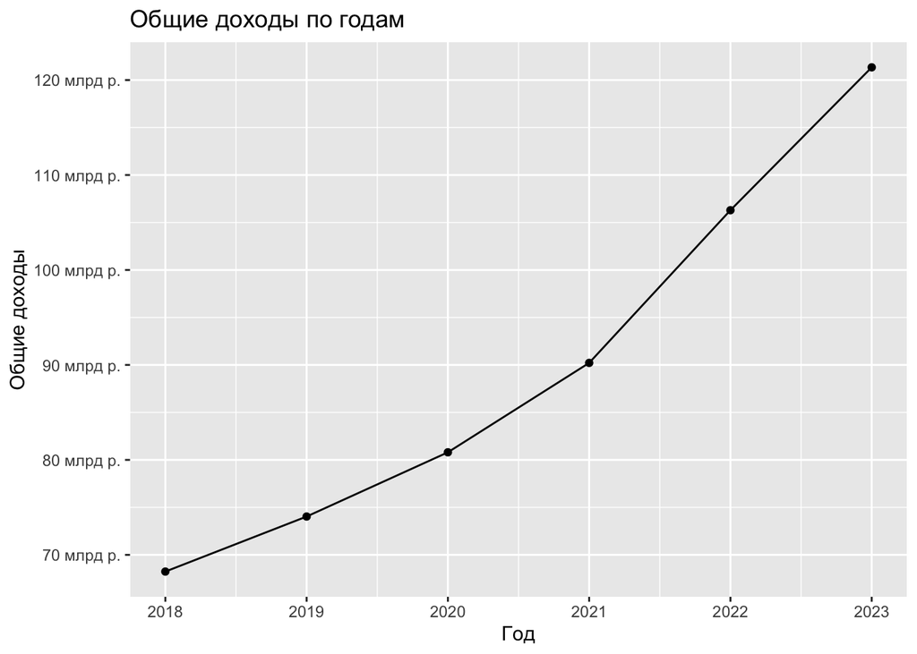

```r
total_income_by_year <- combined_data %>%
  group_by(Год) %>%
  summarise(Общие_доходы = sum(Общие_доходы, na.rm = TRUE))

format_billions <- function(x) {
  paste0(x / 1e9, " млрд р.")
}

ggplot(total_income_by_year, aes(x = Год, y = Общие_доходы)) +
  geom_line() +
  geom_point() +
  labs(title = "Общие доходы по годам",
       x = "Год",
       y = "Общие доходы") +
  scale_y_continuous(labels = format_billions)
```

### Анализ и визуализация

#### Задача 3

**Проанализировать, как изменилась доля социальных выплат в структуре доходов населения муниципальных образований в 2023 году относительно 2018 года и предложить три типа визуализации. Предположить, чем могут объясняться выявленные паттерны.**

Выведем график для динамики долей налогооблагаемых доходов и социальных выплат.

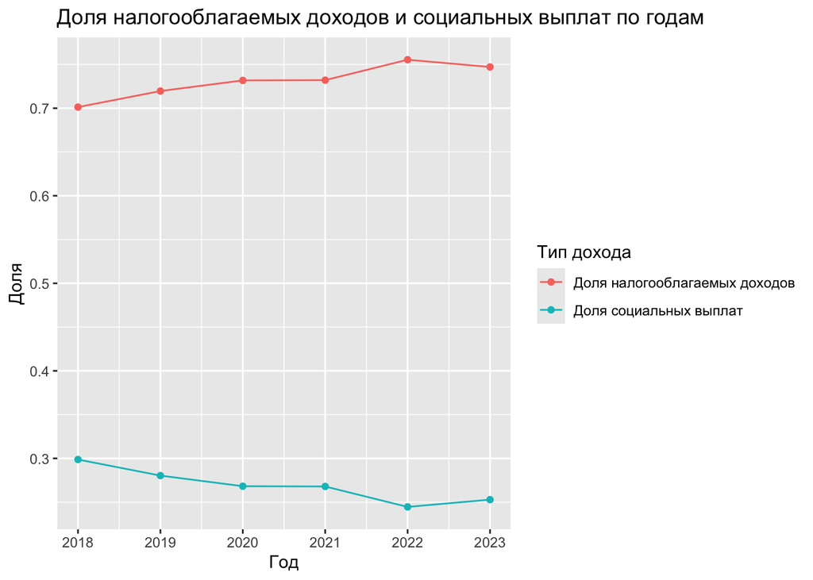

```r
income_share <- combined_data %>%
  group_by(Год) %>%
  summarise(
    `Доля налогооблагаемых доходов` = sum(Налогооблагаемые_доходы, na.rm = TRUE) / sum(Общие_доходы, na.rm = TRUE),
    `Доля социальных выплат` = sum(Социальные_выплаты, na.rm = TRUE) / sum(Общие_доходы, na.rm = TRUE)
  )

income_share_long <- income_share %>%
  tidyr::pivot_longer(cols = c(`Доля налогооблагаемых доходов`, `Доля социальных выплат`),
                      names_to = "Тип_дохода",
                      values_to = "Доля")

ggplot(income_share_long, aes(x = Год, y = Доля, color = Тип_дохода)) +
  geom_line() +
  geom_point() +
  labs(title = "Доля налогооблагаемых доходов и социальных выплат по годам",
       x = "Год",
       y = "Доля",
       color = "Тип дохода")
```

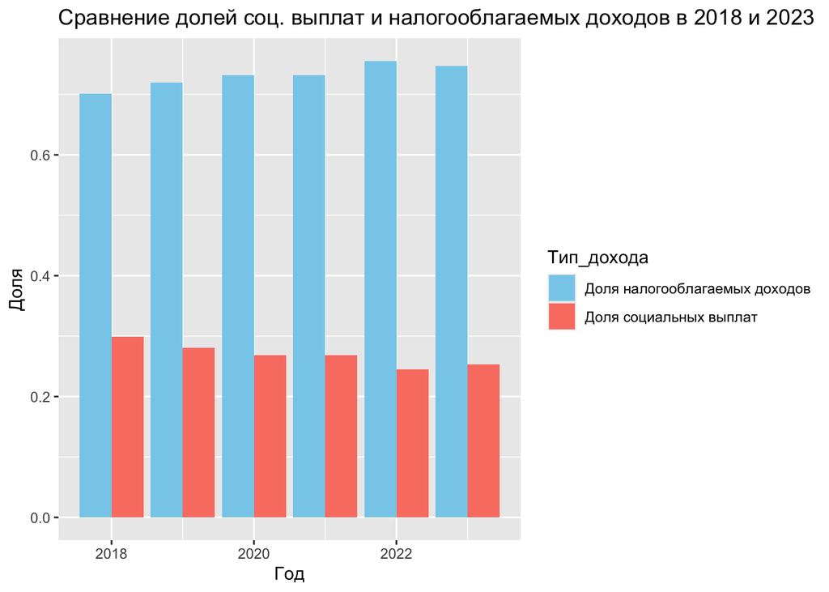

```r
ggplot(income_share_long, aes(x = Год, y = Доля, fill = Тип_дохода)) +
  geom_bar(stat = "identity", position = "dodge") +
  labs(title = "Сравнение долей соц. выплат и налогооблагаемых доходов в 2018 и 2023", x = "Год", y = "Доля",
       color = "Тип дохода") +
  scale_fill_manual(values = c("Доля налогооблагаемых доходов" = "skyblue", "Доля социальных выплат" = "salmon"))
```

3 вариант визуализации – тепловая карта для распределения долей по регионам с 2018 по 2023  
Примечание: это не лучший вариант визуализации, тут следовало бы еще обработать данные, чтобы было более читаемо и понятно.

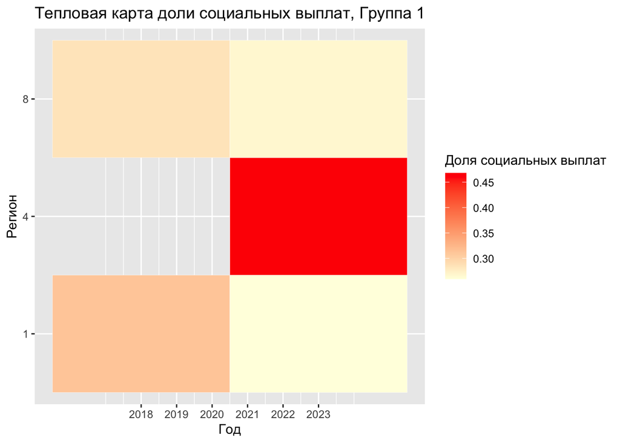

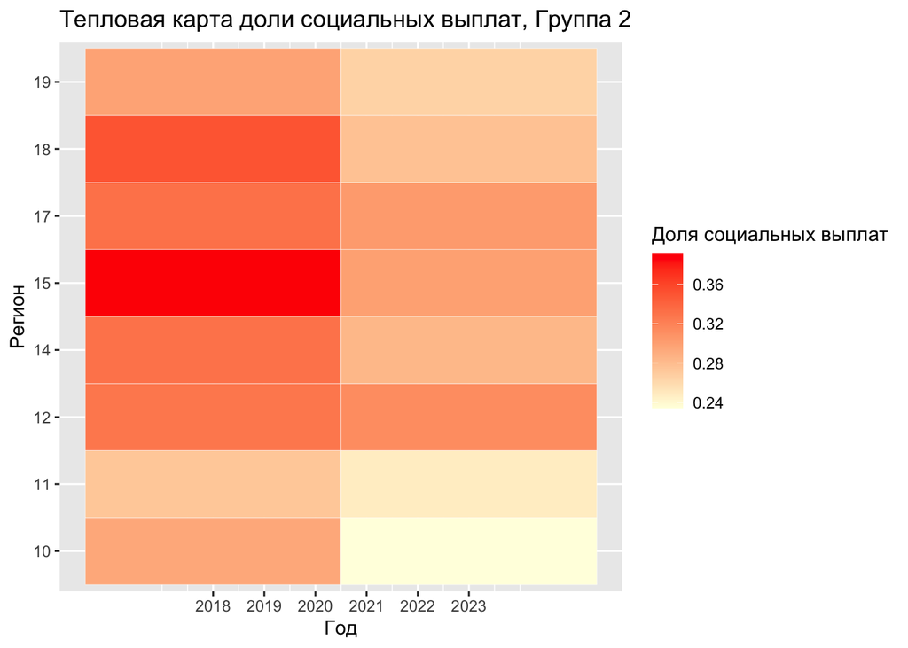

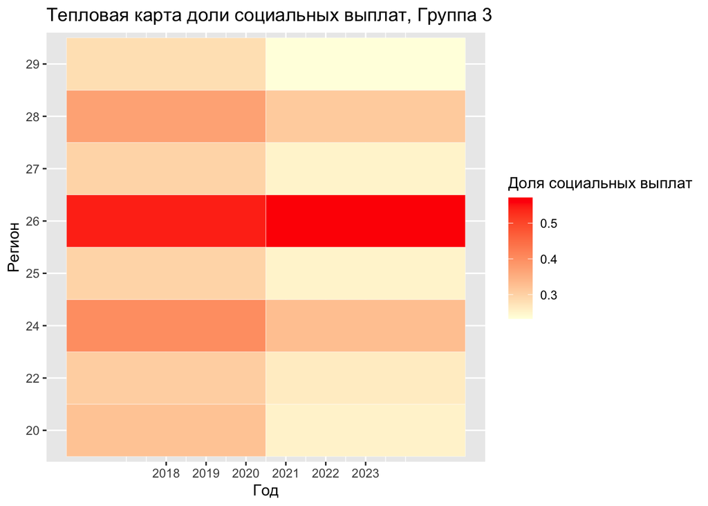

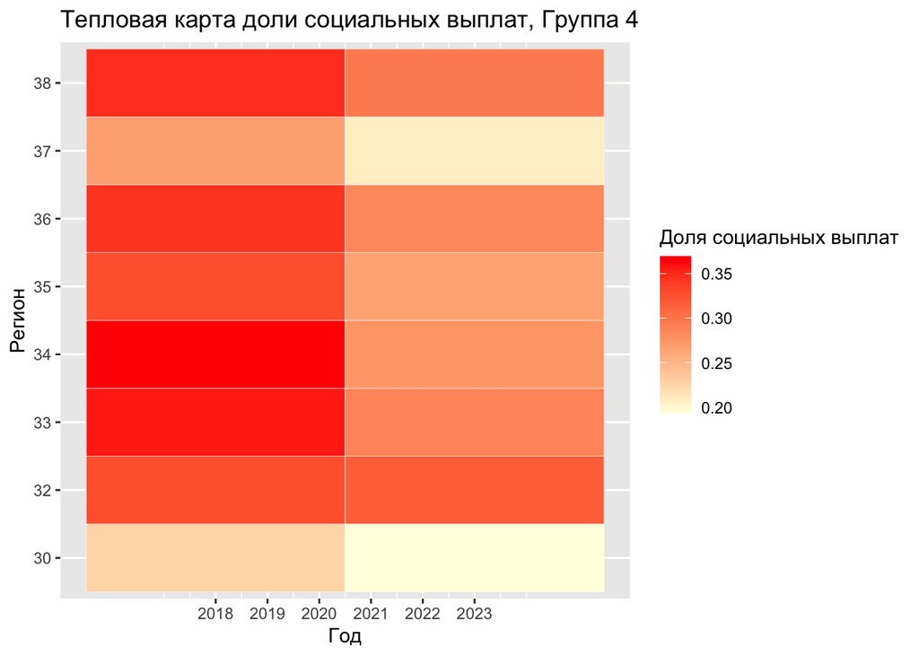

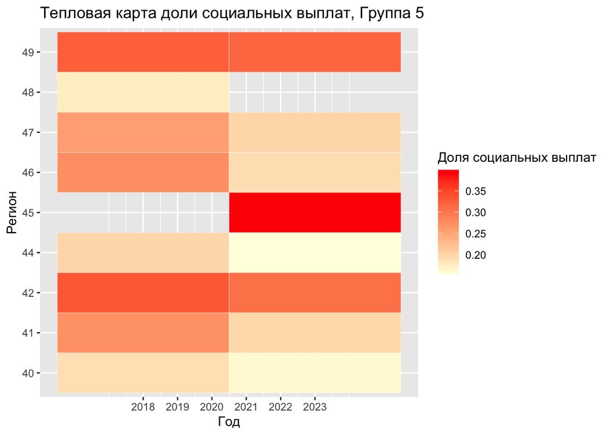

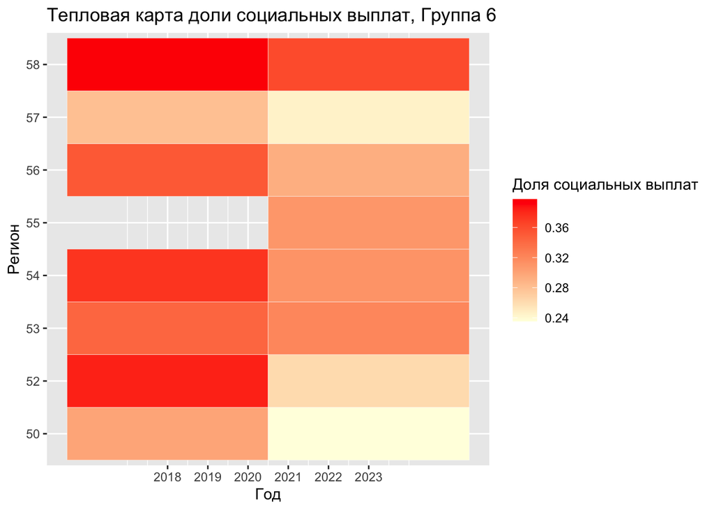

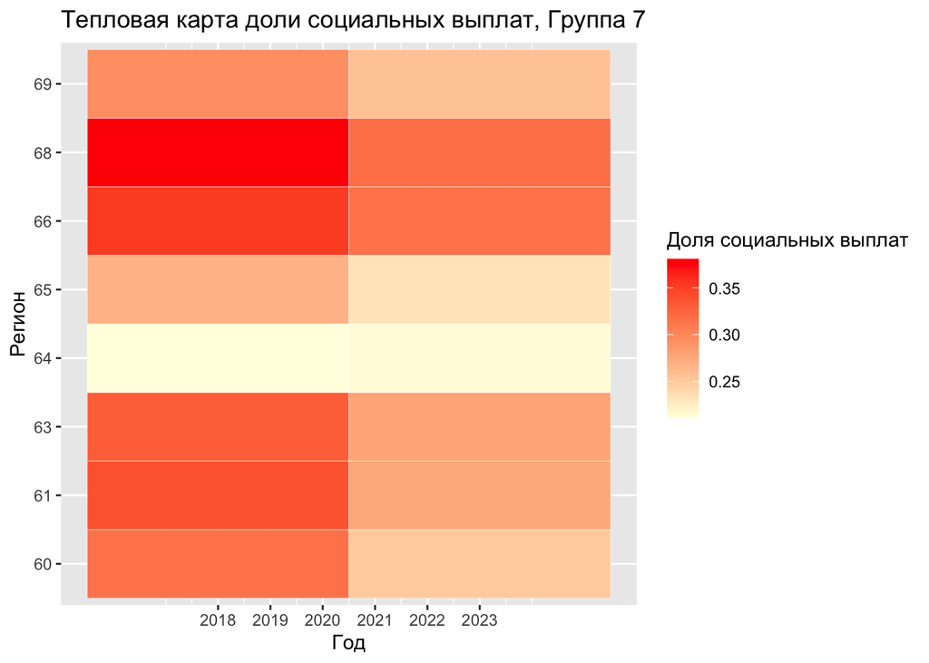

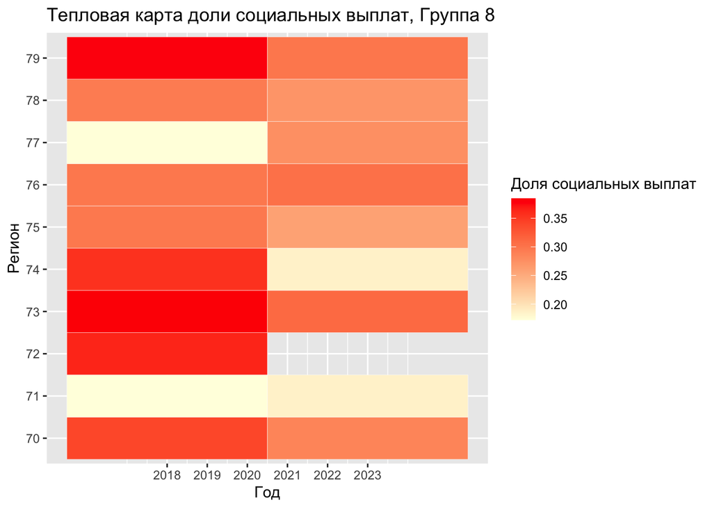

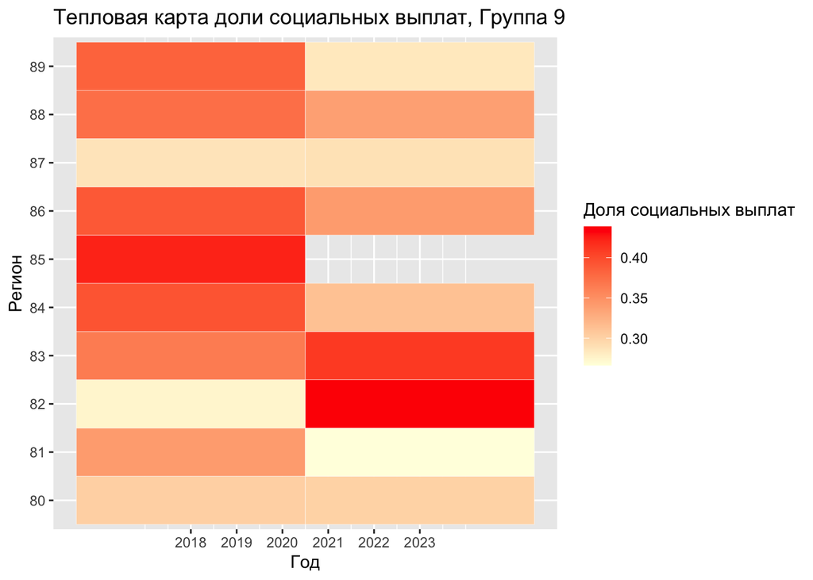

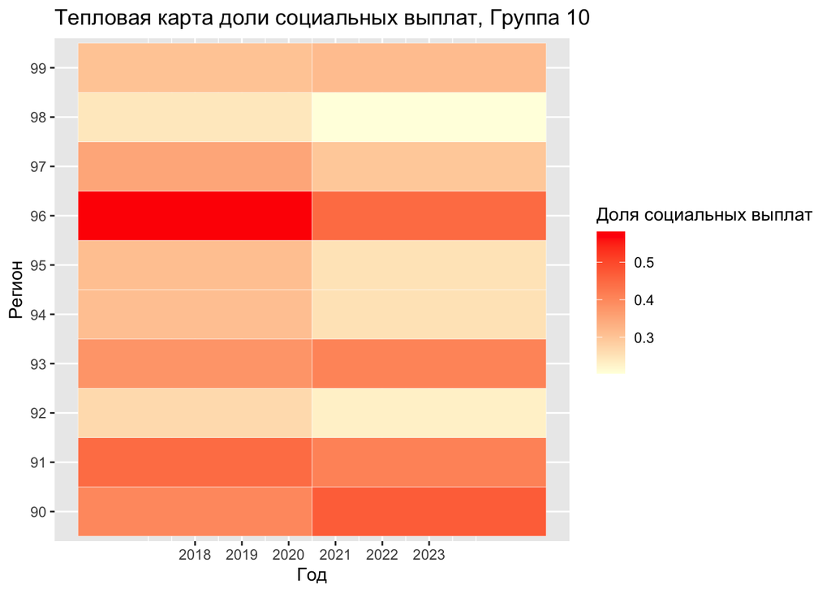

```r
combined_data <- combined_data %>%
  mutate(Регион = as.character(as.numeric(substr(Код_ОКТМО, 1, 2))))

municipality_share <- combined_data %>%
  filter(Год %in% c(2018, 2023)) %>%
  group_by(Год, Регион) %>%
  summarise(
    Доля_социальных_выплат = sum(Социальные_выплаты, na.rm = TRUE) / sum(Общие_доходы, na.rm = TRUE),
    .groups = "drop"
  ) %>%
  mutate(Группа = as.numeric(Регион) %/% 10 + 1)

plots <- list()

for (i in 1:10) {
  p <- ggplot(filter(municipality_share, Группа == i), aes(x = Год, y = Регион, fill = Доля_социальных_выплат)) +
    geom_tile(color = "white") +
    labs(title = paste("Тепловая карта доли социальных выплат, Группа", i),
         x = "Год", y = "Регион", fill = "Доля социальных выплат") +
    scale_fill_gradient(low = "lightyellow", high = "red") +
    scale_x_continuous(breaks = seq(min(municipality_share$Год), max(municipality_share$Год), by = 1))

  plots[[i]] <- p
}

for (i in 1:10) {
  print(plots[[i]])
}
```

### Дизайн исследования

#### Задача 4

*Кратко описать гипотетический дизайн исследования с оценкой влияния реализации инвестиционных проектов в муниципальных образованиях на рост налогооблагаемых денежных доходов населения.*

**Цель исследования:**  
Оценить влияние реализации инвестиционных проектов на рост налогооблагаемых денежных доходов населения муниципальных образований в период 2018-2023 годов.

**Содержательная гипотеза:**  
Инвестиционные проекты способствуют увеличению налогооблагаемых доходов населения за счет роста занятости, доходов от предприятий и улучшения инфраструктуры.

**Метод:**  
Difference-in-Differences, DiD: Сравнить изменения доходов в муниципалитетах с инвестиционными проектами и без них, учитывая изменения до и после внедрения проекта. Регрессионный анализ с фиксированными эффектами: Учесть специфику муниципалитетов (численность населения, уровень безработицы и т.д.), которая может влиять на уровень доходов.

### Комментарии к дизайну

#### Задача 5

*Объяснить как дизайн исследования будет зависеть от механизма имплементации проектов (способ отбора муниципалитетов для участия в программе, учет характеристик муниципальных образований при отборе, масштаб инвестиций, количество муниципалитетов с инвестиционными проектами и т.п.).*

Механизм имплементации проектов напрямую влияет на выбор методик оценки и интерпретацию результатов. Ниже рассмотрим конкретные аспекты влияния.

1. Отбор муниципалитетов  
   Если отбор случайный, это упрощает использование методов, таких как разностный метод (DiD), минимизируя влияние сторонних факторов. При целенаправленном отборе (например, по уровню доходов) потребуется контролировать эти факторы, например, с помощью моделей с фиксированными эффектами.
2. Характеристики муниципалитетов  
   Если отбор учитывает демографические или экономические параметры, важно включить их в модель для снижения искажений. Например, более развитая инфраструктура муниципалитетов может повлиять на исходы, поэтому важно контролировать эти характеристики.
3. Масштаб инвестиций  
   При значительных различиях в объеме инвестиций их следует включить в модель как предиктор. Это позволит оценить, как рост доходов населения связан с масштабом вложений и выявить оптимальные уровни финансирования.
4. Количество муниципалитетов  
   Если охват велик, это повышает статистическую надежность. При малом охвате целесообразно использовать методы подбора контрольных групп (matching), чтобы уменьшить искажения.
5. Направление проектов  
   Разные виды проектов (инфраструктурные, социальные) могут по-разному влиять на доходы. Учёт типа и длительности проектов поможет разделить краткосрочные и долгосрочные эффекты, например, через панельные модели.